# Unidad 1: Herramientas y conceptos básicos de la informática

# Introducción

Si te gusta la lingüística, te va a encantar la programación. Imagínate una lengua que no tiene polisemia ni ambigüedad sintáctica y que una vez que vayas adquiriendo los ítems léxicos, los puedes pronunciar tan bien como cualquier otra persona. En esta unidad, vamos a familiarizarnos con las tecnologías básicas de la programación que usaremos a lo largo del curso.

# 1. ¿Qué es el **shell** y para qué sirve?

[figure not shown]

```r
knitr::include_graphics("https://cdn1.macworld.co.uk/cmsdata/features/3608274/Terminalicon2_thumb800.png")
```

Es una interfaz de línea de comandos que puedes usar para correr programas en tu maquina (u otra máquina disponible en internet (a través de SSH), organizar y navegar por los archivos guardados, y muchas cosas más. Es, sin duda, una de las herramientas más poderosas e importantes que puedes tener como programador (aunque admito que cuando comencé a aprender programar, no veía tanta necesidad de usarlo).

https://www.youtube.com/watch?time_continue=92&v=-EtN5oD8MM0

### Tarea 1: Descargar Git Bash (Solo para usuarios de Windows)

Hecho

Si tienes Windows, vas a necesitar descargar un programa que se llama Git bash. Las instrucciones se pueden encontrar en: [este video](https://www.youtube.com/watch?v=UQZvV6VTlGQ). (50 segundos). Si tienes un Mac, no necesitas hacer nada porque ya cuentas con un programa que se llama *Terminal*.

### Tarea 2: Completar curso de datacamp.com

Hecho Después de haber creado una cuenta en datacamp.com, completa el primer capítulo de este curso:

1. [Introduction to Shell for Data Science](https://www.datacamp.com/courses/introduction-to-shell-for-data-science) (datacamp.com), Chapter 1

# 2. Descargar R y R Studio

R es una lengua de programación igual que Python o Java. Cuando descargues R, vas a ver que puedes abrir un programa que se ve así:

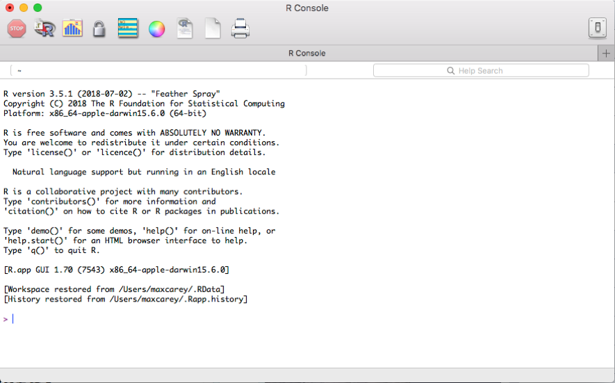

Dentro de este programa puedes usar R. R Studio es un programa que utiliza R pero viene con otras herramientas que se te mejora la experiencia de programar con R.

### Tarea 3: Descargar R y R Studio

Hecho

Sigue [estas instrucciones](https://www.datacamp.com/community/tutorials/installing-R-windows-mac-ubuntu). Para usuarios de Windows, es muy fácil descargar R y R Studio, para usuarios de Mac es un poco más complicado si no tienes experiencia con la línea de comandos.

## Confirma que tienes la versión actualizada de R y R Studio. (Sobre todo si ya tiene un buen desde que los descargaste)

Para checar si tienes la versión más actualizada de R Studio, haz: `help` -> `Check for Updates` (Ve la foto de abajo)

[figure not shown]

# 3. Editores de Texto (Sublime Text)

[figure not shown]

```r
knitr::include_graphics("https://cdn.dribbble.com/users/533705/screenshots/3811091/sublime-icon.png")
```

Los editores de texto son como *Word* pero para códigos. Hay diferentes opciones: Sublime Text, Text Wrangler, Vim, y Nano. Estos programas hacen que proceso de la programación sea mucho menos tedioso, por ejemplo, se subrayan los patrones sintácticos (syntax highlighting) para la lengua dada (*HTML*, *Javascript*, *R*, *Python*) y te ayudan a ver los archivos de forma muy organizada.

### Tarea 4: Descargar Sublime Text

Hecho

Nosotros vamos a estar utilizando Sublime Text y R Studio como los principales editores de texto. Como veremos más adelante, R Studio es un editor de textos (entre muchas otras cosas).

# 4. *Stack Exchange* and *Stack Overflow*

[figure not shown]

[figure not shown]

### Estrategias para usar Stack Overflow

Stack Overflow es un foro donde las personas pueden hacer y contestar preguntas acerca de la programación. Como reddit, los usuarios votan las mejores preguntas, las cuales son promovidas. Stack Exchange se refiere a una red de sitios idénticos a Stack Overflow, pero con [diferentes tópicos](https://stackexchange.com/sites#). Cuando haces una pregunta, es importante seguir la guía para no perder puntos de reputación: (https://stackoverflow.com/help/how-to-ask).

> Founded in 2008, Stack Overflow is the largest, most trusted online community for developers to learn, share their knowledge, and build their careers. More than 50 million professional and aspiring programmers visit Stack Overflow each month to help solve coding problems, develop new skills, and find job opportunities. (https://stackoverflow.com/company)

### Tarea 5: Crear una cuenta en Stack Exchange y explorar los foros

Hecho

Crear una cuenta de Stack Exchange e ir al foro de [lingüística](https://linguistics.stackexchange.com/) y [español](https://spanish.stackexchange.com/). Busca una pregunta para contestar o piensa en una pregunta que podrías hacer. Sin tener mucha experiencia con la programación, estas redes son un buen punto de entrada para aumentar tu reputación en todas las redes de Stack Exchnage. Una vez que hayas adquirido 200 puntos de reputación en algún foro, automáticamente cuentas con 100 puntos al unirte a otro.

# 5. Git y Git Hub

[figure not shown]